# Network and Text Analysis of the book ‘War and Peace’

*August 30, 2021*

## Introduction

The aim of this project is the analysis of a literature text using combinations of methods which are specific of the field of the data science, network science and text mining. The Tolstoy novel “War and Peace”, given the huge number of characters, ambientations, and events that characterize it, it is well suited for this purpose.

## Ambientation

The novel is set in the Europe of the XIX century. Extracting from the text all the capital words and combining them with the words having a hight idf index, where this last one is calculated taking into account even different books, it is possible,with some precautions, to recover all the cities of the novel’s setting.

[interactive chart not shown]

## Characters

Extracting the names of the main character it is quite challenging, because many of them have more then one name, royal appellations and surnames. Some of the main characters of the novel:

```
##                      rostóv                      andrew
##         "count ilyá rostóv"   "andrew bolkónski prince"
##                    nicholas                    princess
## "bolkónski nicholas prince" "bolkónskaya mary princess"
##                      vasíli                     anatole
##     "kurágin prince vasíli"    "anatole kurágin prince"
##                      hélène                    pávlovna
## "bezúkhova countess hélène"     "anna pávlovna schérer"
##                   hippolyte                     rostóva
##  "hippolyte kurágin prince"  "countess natásha rostóva"
##                      joseph                    dmítrich
## "alexéevich bazdéev joseph"   "denísov dmítrich vasíli"
##                    nicholas                    countess
##     "count nicholas rostóv"     "countess rostóva véra"
##                      prince                      prince
##    "kutúzov michael prince" "alexander golítsyn prince"
```

## Characters Interactions

Once the main characters have been extracted, it is useful to find the network of interaction between them. There will be an interaction between two characters whenever they appear together within a section consisting of 6 lines. Whether this choice is appropriate or not depends on the circumstances, The result is an indirect weighted graph, in which the weight of the arcs represents the number of interactions between the linked characters.

## Network of the Characters

Some nodes are not connected with the giant component

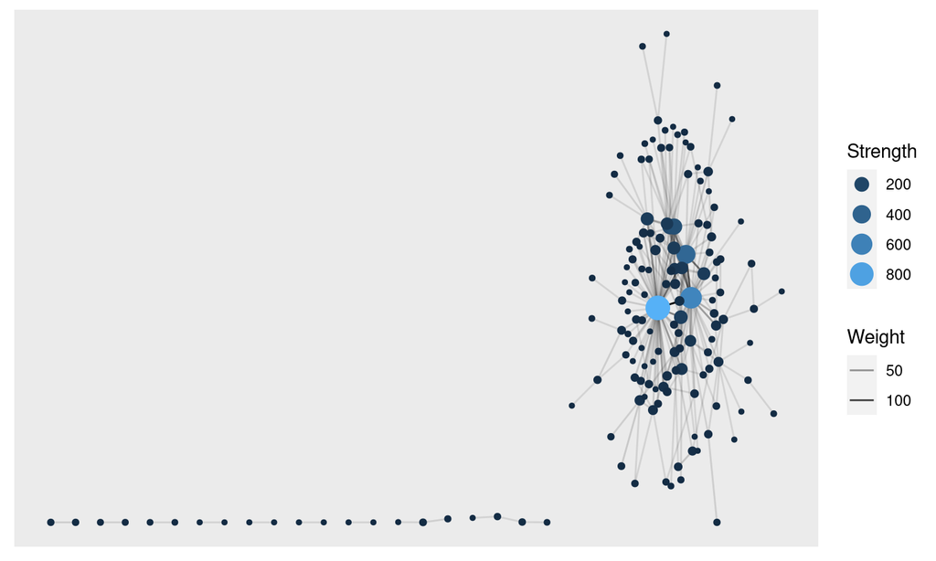

## Giant Component

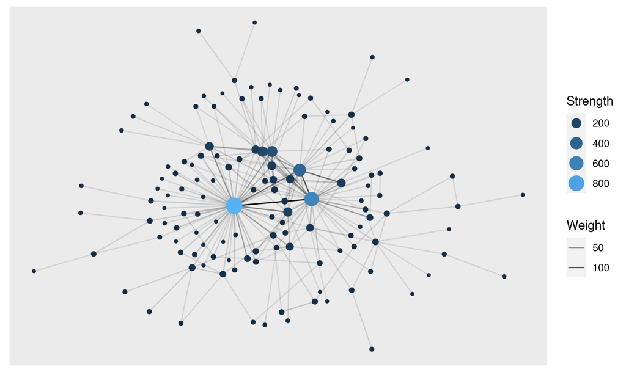

## Strength

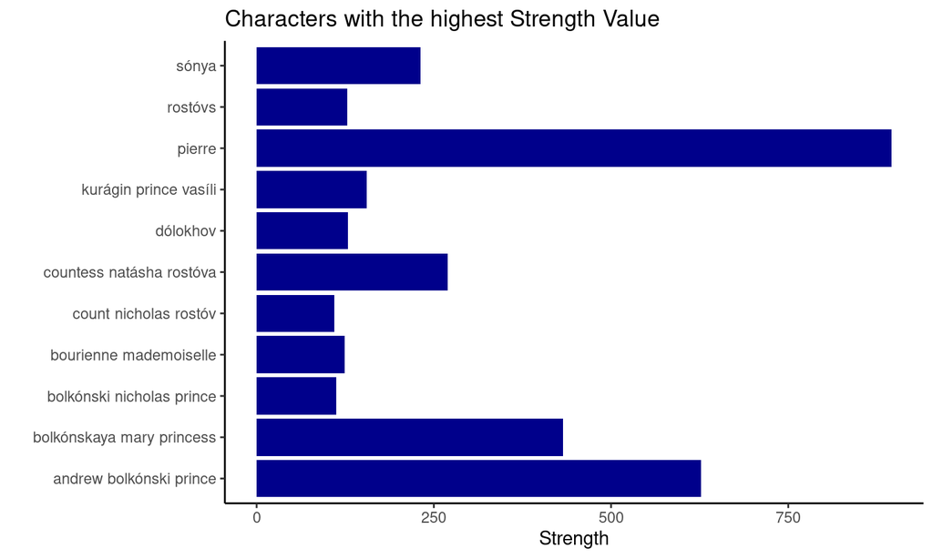

## Degree and Strength Distribution

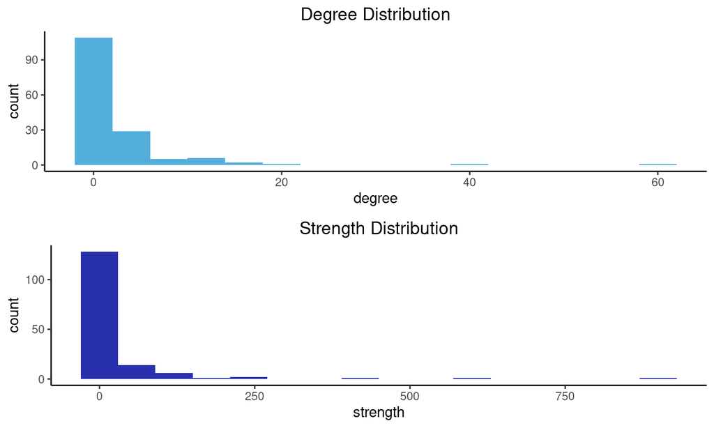

## Power Low Network : degree distribution

Are they Power-Low networks?

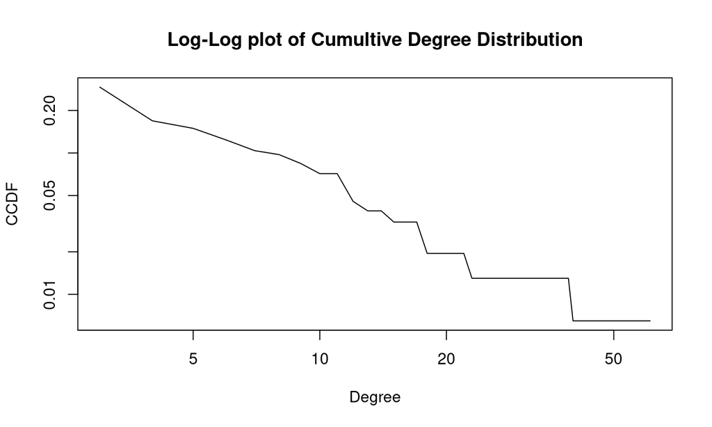

## Strength Distribution

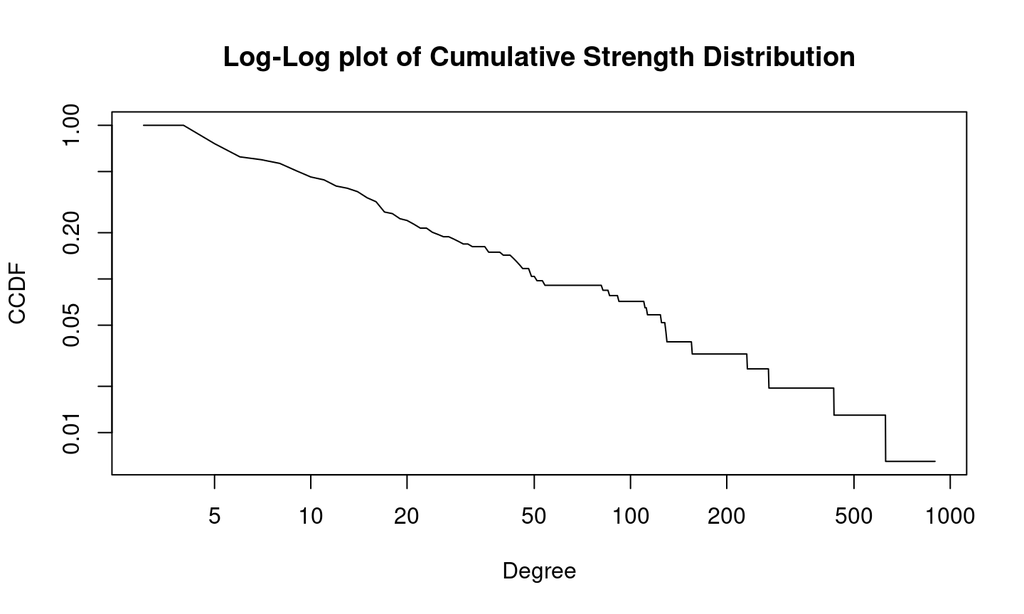

## Betweenneess

Consider betweenneess and closeness centrality. In this case the weights of the network are not considered as a “distance” measure, but on the contrary the greater is the weight of an edge connecting two nodes, the smaller the distance among them.

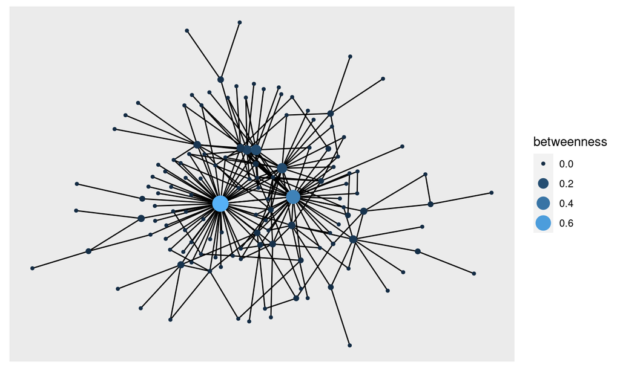

## Closeness

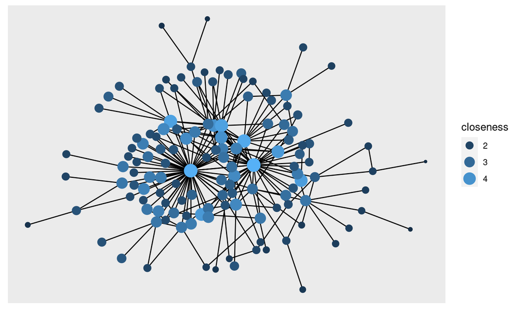

## Robustness of Centrality Measures If the size of the section for the detection of the nodes interactions changes, how the network and the associated centrality measures changes? And how are these measure correlated one respect to the other?

```
##               betweenness closeness degree_data strength_data
## betweenness     1.0000000 0.4672131   0.9533846     0.9625236
## closeness       0.4672131 1.0000000   0.5827881     0.5798050
## degree_data     0.9533846 0.5827881   1.0000000     0.9813908
## strength_data   0.9625236 0.5798050   0.9813908     1.0000000
```

## Robustness of Centrality Measures cont

Correlations among centrality measures among themselves using 6,12 and 18 lines for the dimension of the session

```
##                      df1.bet  df2.bet2  df3.bet3  df1.clos df2.clos2 df3.clos3
## df1.bet            1.0000000 0.9377114 0.9235829 0.4687261 0.4394941 0.4503305
## df2.bet2           0.9377114 1.0000000 0.9599089 0.4785947 0.4549470 0.4635509
## df3.bet3           0.9235829 0.9599089 1.0000000 0.4753398 0.4608547 0.4711083
## df1.clos           0.4687261 0.4785947 0.4753398 1.0000000 0.7875318 0.8203419
## df2.clos2          0.4394941 0.4549470 0.4608547 0.7875318 1.0000000 0.8495695
## df3.clos3          0.4503305 0.4635509 0.4711083 0.8203419 0.8495695 1.0000000
## df1.degree_data    0.9535950 0.8906840 0.8932146 0.5824916 0.5593414 0.5682334
## df2.degree_data2   0.8863837 0.9303704 0.8893416 0.6351835 0.5973906 0.6185713
## df3.degree_data3   0.8743563 0.8882768 0.9184343 0.6541342 0.6377965 0.6166253
## df1.strength_data  0.9625295 0.9001458 0.8913293 0.5813058 0.5471076 0.5484369
## df2.strength_data2 0.9189842 0.9415612 0.9235913 0.6214705 0.6005717 0.6052409
## df3.strength_data3 0.9039833 0.9201373 0.9355266 0.6364830 0.6167720 0.6179338
##                    df1.degree_data df2.degree_data2 df3.degree_data3
## df1.bet                  0.9535950        0.8863837        0.8743563
## df2.bet2                 0.8906840        0.9303704        0.8882768
## df3.bet3                 0.8932146        0.8893416        0.9184343
## df1.clos                 0.5824916        0.6351835        0.6541342
## df2.clos2                0.5593414        0.5973906        0.6377965
## df3.clos3                0.5682334        0.6185713        0.6166253
## df1.degree_data          1.0000000        0.8979318        0.8940030
## df2.degree_data2         0.8979318        1.0000000        0.9295211
## df3.degree_data3         0.8940030        0.9295211        1.0000000
## df1.strength_data        0.9813862        0.9068339        0.9034197
## df2.strength_data2       0.9250817        0.9720141        0.9378006
## df3.strength_data3       0.9175388        0.9381342        0.9702671
##                    df1.strength_data df2.strength_data2 df3.strength_data3
## df1.bet                    0.9625295          0.9189842          0.9039833
## df2.bet2                   0.9001458          0.9415612          0.9201373
## df3.bet3                   0.8913293          0.9235913          0.9355266
## df1.clos                   0.5813058          0.6214705          0.6364830
## df2.clos2                  0.5471076          0.6005717          0.6167720
## df3.clos3                  0.5484369          0.6052409          0.6179338
## df1.degree_data            0.9813862          0.9250817          0.9175388
## df2.degree_data2           0.9068339          0.9720141          0.9381342
## df3.degree_data3           0.9034197          0.9378006          0.9702671
## df1.strength_data          1.0000000          0.9462346          0.9373532
## df2.strength_data2         0.9462346          1.0000000          0.9766760
## df3.strength_data3         0.9373532          0.9766760          1.0000000
```

## Correlation Plot

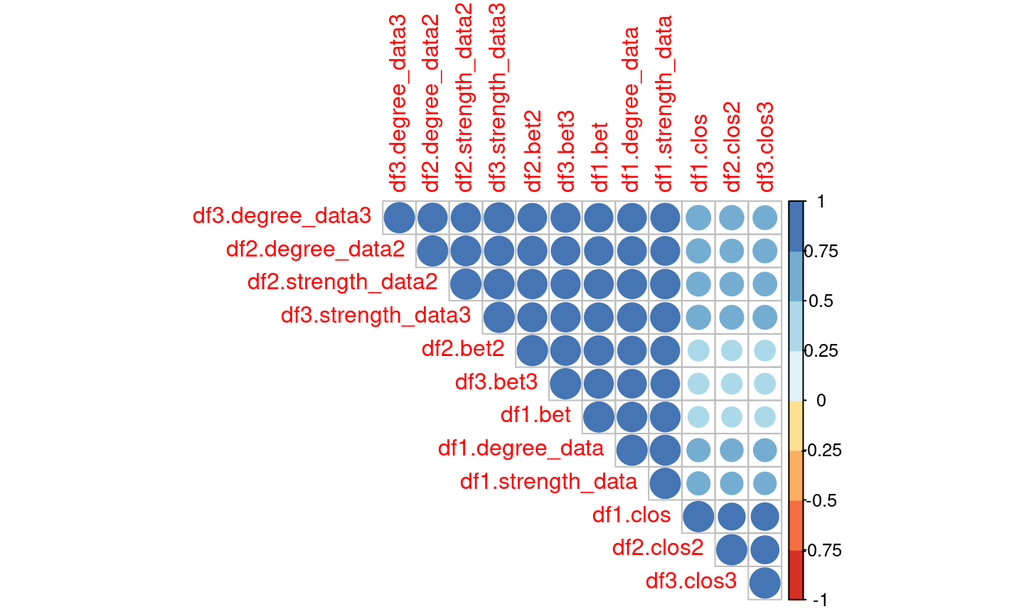

## Community Detection

Louvain Algorithm for community Detection

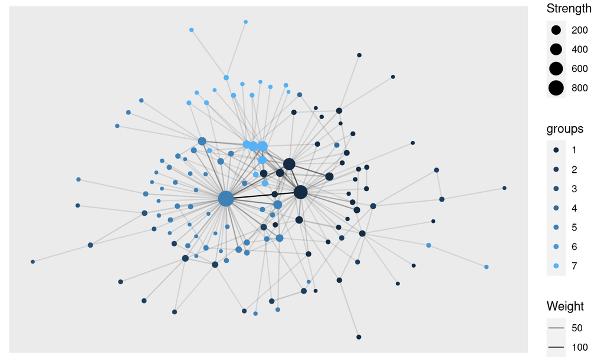

## What is the book about ?

Most used words

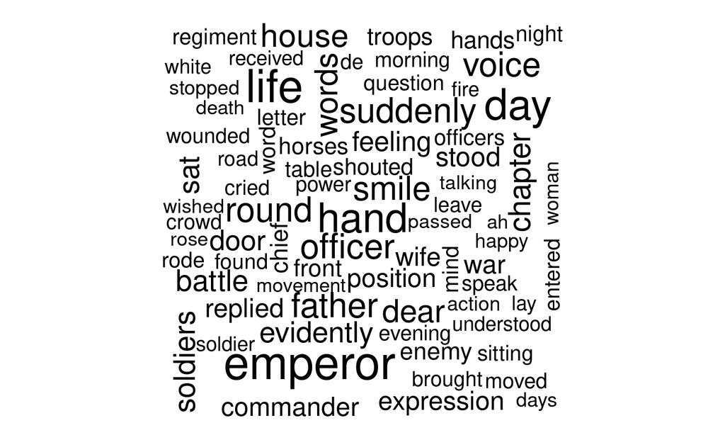

## Sentiment Journey with the main characters

How change the sentiment of the characters among the fifteen books?

[interactive chart not shown]

## Sentiment analysis

From the plot we can detect sudden changes in the character lives, for instance in the case of the character “Pierre”, in the books 12, 13, 14. What happened? it is possible to show a cloud of words related to him and to these books.

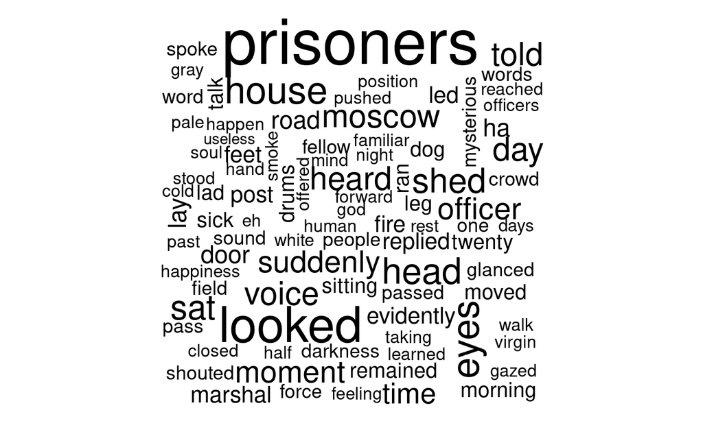

## Conclusion

- As seen, the methods of text analysis have also been found to be useful for revealing the structure of networks, and in turn the methods of network science prove to be useful in analyzing the text.
- The interaction network has proved to be robust to changes in node and edge detection methods, and equally robust were centrality measures such as degree centrality, strength and betweenness.
- Morevore the text analysis allows to understand the main topics of the book and to detect the principal events in the lives of the characters.